# GARAGE

##### BATCH-19

##### Environment Preparation

Steps :

Install the wsl using the command wsl --install in commond prompt/ power shell after installing change the version from 1 to version 2 Then install the docker window and signup the docker window before that restart the computer Now install the the gitbash for windows And type the command cvat inorder to open the cvat. the commands are as follows git clone https://github.com/opencv/cvat cd cvat docker-compose up -d winpty docker exec -it cvat_server bash -ic 'python3 ~/manage.py createsuperuser' enter the username and password Make sure the docker window is ruuning parallel. now we can find that cvat is ruuning and is shiwn in docker window. Installation is done .

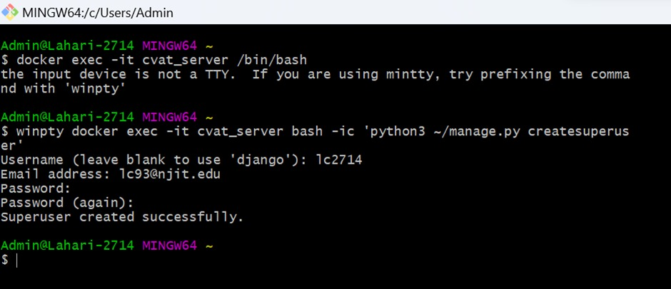

[figure not shown]

#### Data Acquisition

https://colab.research.google.com/drive/1dj_ss4Gk6k9nGV948NC9VP_DKI8Ra8JO#scrollTo=iYLc7IB4hgzR

#### Annotation

Here we take the images and covert them into a dataset having Training and testing data. We Peform Object Segmentation using Deep Extreme Cut (DEXTR). First we create a project in cvat and add the labels to it.

1. The label are named as Wrenches, Screwdrives,shleves, wallpanels,pliers,storage cabinets,workbenches,totes,hammer.
2. then we create a task.
3. Now upload a zip file having a 1000 images
4. Now fit the image in the rectangle and assign the image under correct label
5. Repeat the process for all the 1000 images.
6. make sure each label has a 100 images under it.
7. Now create an coount in roboflow
8. Now convert the fitted images into a MScoco file.
9. Download the zip file.
10. The Zip file is the Dataset
11. It contains test,train,valid and readme file and annotation for the images
12. link for roboflow https://universe.roboflow.com/njit-mhr5p/garage-co4hb 13.link to access the dataset: https://github.com/lc2714/milestone3-

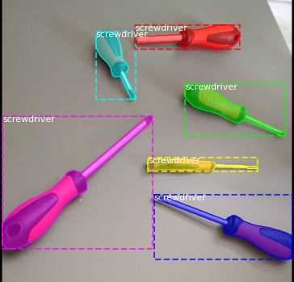

Annotated image of screwdriver

#### Segmentation

MaskRCNN

This architecture is used for instance image segmentation which extends Faster R-CNN (an architecture proposed by Shaoqing Ren et al to eliminate selective search and allow the network to learn region proposals) by adding an object mask predictor as a parallel branch to bounding box recognition.The architecture of MASKRCNN is

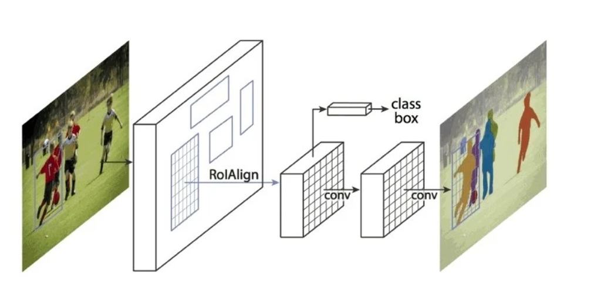